# Experimental Identification of Physically Feasible Dynamic Parameters of the 7-link WAM™ Robot using LMI–SDP Techniques

*Experimental code and data associated with the paper:*

**Cristóvão D. Sousa and Rui Cortesão, "Physical feasibility of robot base inertial parameter identification: A linear matrix inequality approach," The International Journal of Robotics Research, vol. 33, no. 6, pp. 931–944, May. 2014, doi: 10.1177/0278364913514870**

[Postprint availabe from ResearchGate](http://www.researchgate.net/publication/262483999_Physical_feasibility_of_robot_base_inertial_parameter_identification_A_linear_matrix_inequality_approach)

## Authors

- Cristóvão D. Sousa, crisjss@gmail.com
- Rui Cortesão, cortesao@isr.uc.pt

## Research Notebook

The research is done in [Python](http://www.python.org/) within an [IPython notebook](http://ipython.org/notebook.html) (the *WAM7 Dynamic Parameter Identification.ipynb* file). Data is in *data* folder. Additional Python support code is in *support_funcs* folder.

The file *WAM7 Dynamic Parameter Identification.html* is a **preview** of the notebook. **It can be seen online at:**

**[Experimental WAM Robot Dynamic Identification with LMI](http://goo.gl/dOPj8j)**

## How to run the code

- clone the git repository (it contains code and data) from https://github.com/cdsousa/wam7_dyn_ident
- open the *WAM7 Dynamic Parameter Identification.ipynb* notebook with [IPython](http://ipython.org/)
- edit and run the code

Dependencies:

- [Python](http://www.python.org/)
- [IPython](http://ipython.org/)
- [SymPy](http://sympy.org/)
- [Numpy](http://www.numpy.org/)
- [SciPy](http://www.scipy.org/)
- SymPyBotics
- PyLMI-SDP

## Questions & Feedback

Feel free to contact the authors at crisjss@gmail.com

## License

Copyright (c) 2013, Cristóvão Duarte Sousa, Rui Cortesão

All rights reserved.

This work is licensed under a [Creative Commons Attribution-NonCommercial-ShareAlike 4.0 International License](http://creativecommons.org/licenses/by-nc-sa/4.0/)

# Initializations

```python
datafolder = 'data/'
tmpfolder = 'tmp/'
```

```python
from sympy import init_printing
init_printing()

%pylab inline
```

# 1 - Robot Model

```python
import sympybotics
```

#### Robot Definition

```python
rbtdef = sympybotics.RobotDef("xMate7p",
            [(0,       0,      0.404, "q"),
             ("-pi/2", 0,          0, "q"),
             ("pi/2",  0,     0.4375, "q"),
             ("-pi/2", 0,          0, "q"),
             ("pi/2",  0,     0.4125, "q"),
             ("-pi/2", 0,          0, "q"),
             ("pi/2",  0,     0.2755, "q")],
            dh_convention="modified")   # # (alpha, a, d, theta)

# rbtdef.frictionmodel = {}    # 摩擦力模型

# rbtdef.frictionmodel = {'Coulomb', 'viscous'}
# rbtdef.driveinertiamodel = 'simplified'

rbtdef.frictionmodel = {'Coulomb', 'viscous'}
rbtdef.driveinertiamodel = 'simplified'
```

#### Model Generation

```python
%time rbt = sympybotics.RobotDynCode(rbtdef)
%time rbt.calc_base_parms()
```

```
CPU times: user 7.11 s, sys: 80.3 ms, total: 7.19 s
Wall time: 7.14 s
CPU times: user 5.73 s, sys: 96.7 ms, total: 5.83 s
Wall time: 4.13 s
```

```python
import pickle
with open(tmpfolder + 'robotmodels/xMate7p.pkl', 'wb') as file:
    pickle.dump( rbt, file )
```

## Base Dynamic Parameters

```python
import pickle
with open(tmpfolder +  'robotmodels/xMate7p.pkl', 'rb' ) as file:
          rbt = pickle.load( file )
```

```python
rbt.dyn.n_dynparms, rbt.dyn.n_base
```

```
(91, 62)
```

```python
rbt.dyn.baseparms.n()
```

```
Matrix([
[                                                                                                   Ia_1 + L_1zz + L_2yy],
[                                                                                                                   fv_1],
[                                                                                                                   fc_1],
[L_2xx - L_2yy + L_3yy + 0.875*l_3z + 0.19140625*m_3 + 0.19140625*m_4 + 0.19140625*m_5 + 0.19140625*m_6 + 0.19140625*m_7],
[                                                                                                                  L_2xy],
[                                                                                                                  L_2xz],
[                                                                                                                  L_2yz],
[ Ia_2 + L_2zz + L_3yy + 0.875*l_3z + 0.19140625*m_3 + 0.19140625*m_4 + 0.19140625*m_5 + 0.19140625*m_6 + 0.19140625*m_7],
[                                                                                                                   l_2x],
[                                           l_2y - l_3z - 0.4375*m_3 - 0.4375*m_4 - 0.4375*m_5 - 0.4375*m_6 - 0.4375*m_7],
[                                                                                                                   fv_2],
[                                                                                                                   fc_2],
[                                                                                                  L_3xx - L_3yy + L_4yy],
[                                                                                                                  L_3xy],
[                                                                                                                  L_3xz],
[                                                                                                                  L_3yz],
[                                                                                                          L_3zz + L_4yy],
[                                                                                                                   l_3x],
[                                                                                                            l_3y + l_4z],
[                                                                                                                   Ia_3],
[                                                                                                                   fv_3],
[                                                                                                                   fc_3],
[                                  L_4xx - L_4yy + L_5yy + 0.825*l_5z + 0.17015625*m_5 + 0.17015625*m_6 + 0.17015625*m_7],
[                                                                                                                  L_4xy],
[                                                                                                                  L_4xz],
[                                                                                                                  L_4yz],
[                                          L_4zz + L_5yy + 0.825*l_5z + 0.17015625*m_5 + 0.17015625*m_6 + 0.17015625*m_7],
[                                                                                                                   l_4x],
[                                                                     l_4y - l_5z - 0.4125*m_5 - 0.4125*m_6 - 0.4125*m_7],
[                                                                                                                   Ia_4],
[                                                                                                                   fv_4],
[                                                                                                                   fc_4],
[                                                                                                  L_5xx - L_5yy + L_6yy],
[                                                                                                                  L_5xy],
[                                                                                                                  L_5xz],
[                                                                                                                  L_5yz],
[                                                                                                          L_5zz + L_6yy],
[                                                                                                                   l_5x],
[                                                                                                            l_5y + l_6z],
```

[output cut: 8 more lines]

```
[                                                                                                                   l_6x],
[                                                                                               l_6y - l_7z - 0.2755*m_7],
[                                                                                                                   Ia_6],
[                                                                                                                   fv_6],
[                                                                                                                   fc_6],
[                                                                                                          L_7xx - L_7yy],
[                                                                                                                  L_7xy],
[                                                                                                                  L_7xz],
[                                                                                                                  L_7yz],
[                                                                                                                  L_7zz],
[                                                                                                                   l_7x],
[                                                                                                                   l_7y],
[                                                                                                                   Ia_7],
[                                                                                                                   fv_7],
[                                                                                                                   fc_7]])
```

# 2 - Excited Trajectory Optimization

```python
import pickle
with open(tmpfolder +  'robotmodels/xMate7p.pkl', 'rb' ) as file:
          rbt = pickle.load( file )
```

```python
from trajectory_optimization import TrajOptimizer
from trajectory_optimization import TrajPlotter
from numpy import deg2rad

trajectory_folder =  'data/trajectories/'

# 周期是20
base_freq = 0.05
fourier_order = 5

joint_constraints = []

# 关节约束[关节序号，位置约束，速度约束，加速度约束]
joint_constraints = [(1, deg2rad(-165), deg2rad(165), -2.175, 2.175, -15, 15),
                     (2, deg2rad(-115), deg2rad(115), -2.175, 2.175, -7.5, 7.5),
                     (3, deg2rad(-165), deg2rad(165), -2.175, 2.175, -10, 10),
                     (4, deg2rad(-115), deg2rad(115), -2.175, 2.175, -10, 10),
                     (5, deg2rad(-165), deg2rad(165), -2.610, 2.610, -15, 15),
                     (6, deg2rad(-115), deg2rad(115), -2.610, 2.610, -15, 15),
                     (7, deg2rad(-355), deg2rad(355), -2.610, 2.610, -20, 20)]


# # 关节约束[关节序号，位置约束，速度约束，加速度约束]
# joint_constraints = [(1, deg2rad(-165), deg2rad(165), -2.175, 2.175),
#                      (2, deg2rad(-115), deg2rad(115), -2.175, 2.175),
#                      (3, deg2rad(-165), deg2rad(165), -2.175, 2.175),
#                      (4, deg2rad(-115), deg2rad(115), -2.175, 2.175),
#                      (5, deg2rad(-165), deg2rad(165), -2.610, 2.610),
#                      (6, deg2rad(-115), deg2rad(115), -2.610, 2.610),
#                      (7, deg2rad(-355), deg2rad(355), -2.610, 2.610)]

traj_optimizer = TrajOptimizer(rbt, fourier_order, base_freq,
                               joint_constraints=joint_constraints)

traj_optimizer.x_result = np.load(trajectory_folder+"opt_x.npy")
# traj_optimizer.optimize()
```

```
dof_num: 7
joint constraint number: 42
cartesian constraint number: 0
constraint number: 42
frames_constrained: []
```

## plot excited trajectory

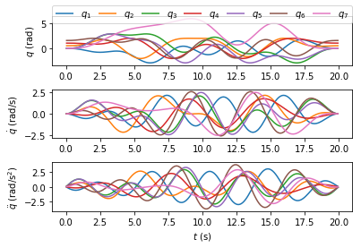

```python
# %matplotlib qt

traj_plotter = TrajPlotter(traj_optimizer.fourier_traj,traj_optimizer.frame_traj,
                           traj_optimizer.const_frame_ind)
traj_plotter.plot_desired_traj(traj_optimizer.x_result, trajectory_folder)
```

## save trajectory

```python
from utils import save_data, load_data

trajectory_name = 'xMate7p'

dof_order_bf_x_norm = (traj_optimizer.fourier_traj.dof, fourier_order,
                       base_freq, traj_optimizer.x_result, [])
save_data(trajectory_folder, trajectory_name, dof_order_bf_x_norm)

freq = 50
tf = 65 # including 5 seconds' prestable time
traj_optimizer.make_traj_csv(trajectory_folder, trajectory_name, freq, tf)


# save as .npy format in order to skip the optimizer
np.save(trajectory_folder+"opt_x.npy", traj_optimizer.x_result)

# save as .txt format for xMate7 pro robot
opt_x = [0]*traj_optimizer.fourier_traj.dof*(2*fourier_order+1)
for i in range(traj_optimizer.fourier_traj.dof):
    opt_x[i*11] = traj_optimizer.x_result.tolist()[i*11+1]
    opt_x[i*11+1] = traj_optimizer.x_result.tolist()[i*11+6]
    opt_x[i*11+2] = traj_optimizer.x_result.tolist()[i*11+2]
    opt_x[i*11+3] = traj_optimizer.x_result.tolist()[i*11+7]
    opt_x[i*11+4] = traj_optimizer.x_result.tolist()[i*11+3]
    opt_x[i*11+5] = traj_optimizer.x_result.tolist()[i*11+8]
    opt_x[i*11+6] = traj_optimizer.x_result.tolist()[i*11+4]
    opt_x[i*11+7] = traj_optimizer.x_result.tolist()[i*11+9]
    opt_x[i*11+8] = traj_optimizer.x_result.tolist()[i*11+5]
    opt_x[i*11+9] = traj_optimizer.x_result.tolist()[i*11+10]
    opt_x[i*11+10] = traj_optimizer.x_result.tolist()[i*11+0]

# list_txt(path=trajectory_folder+'opt_x.txt', list=opt_x)
f1 = open(trajectory_folder+'opt_x.txt','w')
for j in opt_x:
    f1.write(str(j)+'\n')
f1.close()
q, dq, ddq = traj_optimizer.fourier_traj.fourier_base_x2q(traj_optimizer.x_result)
q[0]
```

```
array([-4.82916904e-06,  5.23596413e-01,  1.37229307e-06,  1.04719678e+00,
        7.87726298e-08,  1.57079639e+00,  8.11783698e-08])
```

## display trajectory param

```python
from IPython.display import HTML, display
import tabulate

table = []
table.append(["joint", 'qo'] +
             ["a"+str(i+1) for i in range(fourier_order)] +
             ["b"+str(i+1) for i in range(fourier_order)])
for i in range(traj_optimizer.fourier_traj.dof):
    line = []
    line.append(rbt.rbtdef.q[i])
    line += np.round(traj_optimizer.x_result[i*(1 + fourier_order*2): (i+1)*(1 + fourier_order*2)], 4).tolist()
    table.append(line)

display(HTML(tabulate.tabulate(table, tablefmt='html')))
```

| joint | qo | a1 | a2 | a3 | a4 | a5 | b1 | b2 | b3 | b4 | b5 |
| --- | --- | --- | --- | --- | --- | --- | --- | --- | --- | --- | --- |
| q1 | -0.3539 | -0.279 | 0.0057 | -0.211 | -0.5009 | 0.9852 | -0.1038 | -0.3361 | 0.241 | 0.8687 | -0.6844 |
| q2 | 0.5707 | -0.0525 | -0.1808 | 0.7247 | 0.1709 | -0.6634 | -0.0046 | -0.5089 | 1.0307 | 0.1451 | -0.53 |
| q3 | 0.4304 | 0.6088 | 0.6038 | -0.5058 | 0.4032 | -1.1101 | 0.1377 | 0.1008 | -0.0157 | -0.3998 | 0.2614 |
| q4 | 0.3987 | 0.0479 | -0.1241 | -0.4313 | 0.4425 | 0.065 | -0.3813 | 0.1297 | 0.8641 | -0.8496 | 0.1856 |
| q5 | -0.3251 | 0.5573 | 0.5621 | -0.6522 | 0.6892 | -1.1565 | -0.2269 | 0.1727 | 0.3031 | -0.2388 | -0.0145 |
| q6 | 0.4889 | 0.2006 | 0.3843 | 0.0493 | 0.1479 | -0.7822 | -0.242 | 0.0325 | 0.0177 | -1.3887 | 1.1358 |
| q7 | 2.8145 | 0.1887 | -0.6329 | 0.7967 | -0.0096 | -0.3429 | 0.6124 | 0.5486 | 0.7155 | -0.9636 | -0.0003 |

# 3 - Regression Data Processing

```python
import os
import pickle
import math
import sympy
import numpy
import sympybotics
```

```python
with open(tmpfolder +  'robotmodels/xMate7p.pkl', 'rb' ) as file:
          rbt = pickle.load( file )
```

### Data Load

```python
parms_traj = 'traj1'
```

```python
from support_funcs.regr_data_proc import load_trajectory_data

training_results_data_file = datafolder +'recdata/' + 'xMate7p_'+parms_traj+'_results.csv'

trajectory_sampling_rate = 50    # 实际机器人数据采样频率，用于计算时间
t_raw, q_raw, dq_raw, tau_raw = load_trajectory_data(training_results_data_file,
                                                                   trajectory_sampling_rate)
t_raw.shape
```

```
(<type 'numpy.ndarray'>, (3001, 21))
```

```
(3001,)
```

### Some Plots

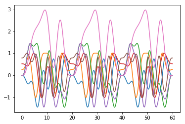

```python
from matplotlib import pyplot as plt
plt.close()

# for d in range(rbt.dof):
#     co_num = str(d + 1)
#     plt.plot(t_raw, q_raw[:, d], label=(r"$q_" + co_num +"$"), linestyle= (0, ()))

for i in range(q_raw.shape[1]):
    plt.plot(t_raw,q_raw[:,i])

plt.show()
```

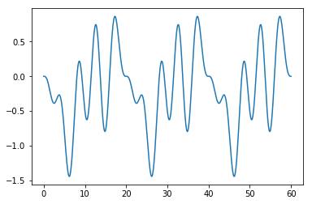

```python
from matplotlib import pyplot as plt
plt.close()

joint = 1
# plt.plot(t_ref+0.20,q_ref[:,joint-1])
plt.plot(t_raw,q_raw[:,joint-1])

plt.show()
```

```python
del t_raw, q_raw, dq_raw,tau_raw
```

### Parameter Load

```python
from utils import save_data, load_data

training_trajectory_name = 'xMate7p'


trajectory_folder = datafolder +'trajectories/'
dof, fourier_order, base_freq, traj_optimizer_result, reg_norm_mat = load_data(trajectory_folder,
                                                                               training_trajectory_name)
print("dof: {}".format(dof))
print("Fourier order: {}".format(fourier_order))
print("Base frequency: {}".format(base_freq))
```

```
dof: 7
Fourier order: 5
Base frequency: 0.05
```

### Filter Cut-off Frequency Definition

```python
# times of the highest frequency in the Fourier series
fc_mult = 10.0

fc = base_freq * fourier_order * fc_mult
print("Cut frequency: {}".format(fc))
```

```
Cut frequency: 2.5
```

```python
fc_q = fc
fc_dq = fc
fc_ddq = fc

fc_tau = float('Inf')  # fc

si = 200
sf = -200
```

### Data Filtering, Differentiation and Regression Data Generation

```python
rec_h = 0.02
```

```python
from support_funcs.regr_data_proc import load_trajectory_data, plot_trajectory_data, \
                                            diff_and_filt_data, gen_regr_matrices


def process_regression_data(traj_name):
#     t_raw, q_raw, tau_raw, t_ref, q_ref = read_data(dof=rbt.dof, h=rec_h,
#                                                     rbtlogfile=datafolder + 'recdata/rbtlog_%s.dat'%traj_name,
#                                                     trajreffile=datafolder + 'trajectories/%s.dat'%traj_name)

    training_results_data_file = datafolder +'recdata/' + 'xMate7p_%s_results.csv'%traj_name
    trajectory_sampling_rate = 50    # 采样频率是50hz
    t_raw, q_raw, dq_raw, tau_raw = load_trajectory_data(training_results_data_file,
                                                                   trajectory_sampling_rate)

    # 原始采集数据滤波
    q, dq, ddq, tau = diff_and_filt_data(dof=rbt.dof, h=rec_h,  q_raw=q_raw, tau_raw=tau_raw,
                                   fc_q=fc_q, fc_dq=fc_dq, fc_ddq=fc_ddq, fc_tau=fc_tau)

    # 掐头去尾留中间，可能是因为开始和结束时抖动？
    t_raw = t_raw[si:sf]; q_raw = q_raw[si:sf]; tau_raw = tau_raw[si:sf]
    q = q[si:sf]; dq = dq[si:sf]; ddq = ddq[si:sf]; tau = tau[si:sf]


    t_raw = t_raw - t_raw[0]

    t = numpy.array(range(q.shape[0])) * rec_h

    W, omega, Q1, R1, rho1 = gen_regr_matrices(rbt, q, dq, ddq, tau)

    # t_raw, q_raw, tau_raw是原始采集数据，t, q, dq, ddq, tau是滤波后的数据
    return t_raw, q_raw, tau_raw, t, q, dq, ddq, tau, W, omega, Q1, R1, rho1
```

```
>>>>>>>> traj1 proc <<<<<<<<<
(<type 'numpy.ndarray'>, (3001, 21))
CPU times: user 1.64 s, sys: 55.9 ms, total: 1.69 s
Wall time: 607 ms
 (cond=81.716953)
traj1 save
CPU times: user 1.36 s, sys: 28.2 ms, total: 1.39 s
Wall time: 718 ms
plot shape: 470
```

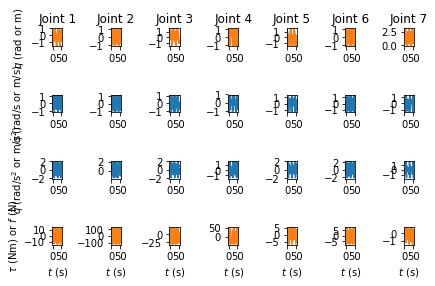

```
>>>>>>>> traj2 proc <<<<<<<<<
(<type 'numpy.ndarray'>, (3001, 21))
CPU times: user 1.64 s, sys: 35.6 ms, total: 1.67 s
Wall time: 588 ms
 (cond=133.550534)
traj2 save
CPU times: user 1.36 s, sys: 24.3 ms, total: 1.38 s
Wall time: 735 ms
plot shape: 470
```

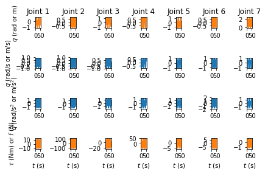

```
>>>>>>>> traj3 proc <<<<<<<<<
(<type 'numpy.ndarray'>, (3001, 21))
CPU times: user 1.67 s, sys: 15.7 ms, total: 1.68 s
Wall time: 590 ms
 (cond=54.831491)
traj3 save
CPU times: user 1.31 s, sys: 36 ms, total: 1.34 s
Wall time: 704 ms
plot shape: 470
```

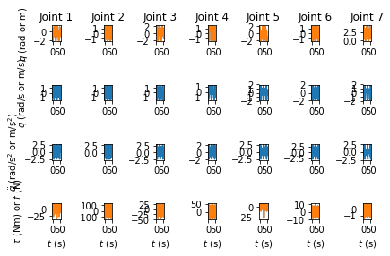

```python
from support_funcs.utils import _fprint
from support_funcs.regr_data_proc import plot_trajectory_data

for traj in ['traj1', 'traj2', 'traj3']:      #, 'traj4'
    _fprint('>>>>>>>> %s proc <<<<<<<<<'%traj)
    %time t_raw, q_raw, tau_raw, t, q, dq, ddq, tau, W, omega, Q1, R1, rho1 = process_regression_data(traj)

    _fprint(' (cond=%f)'%numpy.linalg.cond(W))

    _fprint('%s save'%traj)

    %time \
    numpy.savez_compressed(tmpfolder + 'procdata/' + traj + '_raw', t=t_raw, q=q_raw, tau=tau_raw);\
    numpy.savez_compressed(tmpfolder + 'procdata/' + traj + '_proc', t=t, q=q, dq=dq, ddq=ddq, tau=tau); \
    numpy.savez_compressed(tmpfolder + 'procdata/' + traj + '_regr', W=W, omega=omega, Q1=Q1, R1=R1, rho1=rho1)

    plot_trajectory_data(t, q_raw, q, dq, ddq,
                     tau_raw, tau)

    del t_raw, q_raw, tau_raw, t, q, dq, ddq, tau, W, omega, Q1, R1, rho1
```

### Plot

```python
raw = numpy.load(tmpfolder + 'procdata/traj1_raw.npz')
tau_raw = raw['tau']
q_raw = raw['q']
del raw
proc = numpy.load(tmpfolder + 'procdata/traj1_proc.npz')
t = proc['t']
tau = proc['tau']
q = proc['q']
dq = proc['dq']
del proc
```

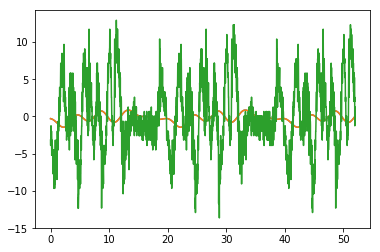

```python
from matplotlib import pyplot as plt
plt.close()

joint = 1
firsts = 20000
plt.plot(t[:firsts],q_raw[:,joint-1][:firsts])
plt.plot(t[:firsts],q[:,joint-1][:firsts])
#plt.plot(t[:firsts],dq[:,joint-1][:firsts])
plt.plot(t[:firsts],tau_raw[:,joint-1][:firsts])

plt.show()
```

```python
del t, q, dq, tau, q_raw, tau_raw
```

# 4 - Dynamic Parameter Estimation

```python
import os
import pickle
import sympy
import numpy
import time

import sympybotics
import lmi_sdp

from lmi_sdp import init_lmi_latex_printing
init_lmi_latex_printing()
```

```python
with open(tmpfolder +  'robotmodels/xMate7p.pkl', 'rb' ) as file:
          rbt = pickle.load( file )
```

```python
epsilon_safemargin = 1e-6
epsilon_sdptol = 1e-7
```

## LMI Matrix Definitions

```python
dof = rbt.dof

delta = rbt.dyn.dynparms    # 要辨识的全参数集矩阵表达式
n_delta = rbt.dyn.n_dynparms    # 要辨识的全参数集参数数量

beta = rbt.dyn.baseparms.n()    # 最小参数集矩阵表达式
n_beta = rbt.dyn.n_base         # 最小参数集参数数量
beta_symbs = sympy.Matrix([sympy.Symbol('beta'+str(i+1),real=True) for i in range(n_beta)])

delta_d = (rbt.dyn.Pd.T*delta)
n_delta_d = len(delta_d)

Pb = rbt.dyn.Pb

varchange_dict = dict(zip(Pb.T*delta ,  beta_symbs - ( beta - Pb.T*delta )))
```

```python
from support_funcs.utils import skew, mrepl
from sympy import BlockMatrix, Matrix, eye, Identity
I = Identity
S = skew
```

```python
D_inertia_blocks = []
# l是一阶矩，表征的是连杆的质心，L是连杆的惯性张量，m是连杆质量
for i in range(dof):
    L = rbt.rbtdef.L[i]
    l = rbt.rbtdef.l[i]
    m = rbt.rbtdef.m[i]
    Di = BlockMatrix([[L,    S(l).T],
                      [S(l), I(3)*m]])
    D_inertia_blocks.append(Di.as_explicit())
```

```python
D_inertia_blocks[0]
```

```
Matrix([
[L_1xx, L_1xy, L_1xz,     0,  l_1z, -l_1y],
[L_1xy, L_1yy, L_1yz, -l_1z,     0,  l_1x],
[L_1xz, L_1yz, L_1zz,  l_1y, -l_1x,     0],
[    0, -l_1z,  l_1y,   m_1,     0,     0],
[ l_1z,     0, -l_1x,     0,   m_1,     0],
[-l_1y,  l_1x,     0,     0,     0,   m_1]])
```

```python
D_other_blocks = []
for i in range(dof):
    if rbt.rbtdef.driveinertiamodel == 'simplified':
        D_other_blocks.append( Matrix([rbt.rbtdef.Ia[i]]) )
    if 'viscous' in rbt.rbtdef.frictionmodel:
        D_other_blocks.append( Matrix([rbt.rbtdef.fv[i]]) )
    if 'Coulomb' in rbt.rbtdef.frictionmodel:
        D_other_blocks.append( Matrix([rbt.rbtdef.fc[i]]) )
```

```python
D_blocks = D_inertia_blocks + D_other_blocks
```

```python
D_blocks
```

```
[Matrix([
 [L_1xx, L_1xy, L_1xz,     0,  l_1z, -l_1y],
 [L_1xy, L_1yy, L_1yz, -l_1z,     0,  l_1x],
 [L_1xz, L_1yz, L_1zz,  l_1y, -l_1x,     0],
 [    0, -l_1z,  l_1y,   m_1,     0,     0],
 [ l_1z,     0, -l_1x,     0,   m_1,     0],
 [-l_1y,  l_1x,     0,     0,     0,   m_1]]), Matrix([
 [L_2xx, L_2xy, L_2xz,     0,  l_2z, -l_2y],
 [L_2xy, L_2yy, L_2yz, -l_2z,     0,  l_2x],
 [L_2xz, L_2yz, L_2zz,  l_2y, -l_2x,     0],
 [    0, -l_2z,  l_2y,   m_2,     0,     0],
 [ l_2z,     0, -l_2x,     0,   m_2,     0],
 [-l_2y,  l_2x,     0,     0,     0,   m_2]]), Matrix([
 [L_3xx, L_3xy, L_3xz,     0,  l_3z, -l_3y],
 [L_3xy, L_3yy, L_3yz, -l_3z,     0,  l_3x],
 [L_3xz, L_3yz, L_3zz,  l_3y, -l_3x,     0],
 [    0, -l_3z,  l_3y,   m_3,     0,     0],
 [ l_3z,     0, -l_3x,     0,   m_3,     0],
 [-l_3y,  l_3x,     0,     0,     0,   m_3]]), Matrix([
 [L_4xx, L_4xy, L_4xz,     0,  l_4z, -l_4y],
 [L_4xy, L_4yy, L_4yz, -l_4z,     0,  l_4x],
 [L_4xz, L_4yz, L_4zz,  l_4y, -l_4x,     0],
 [    0, -l_4z,  l_4y,   m_4,     0,     0],
 [ l_4z,     0, -l_4x,     0,   m_4,     0],
 [-l_4y,  l_4x,     0,     0,     0,   m_4]]), Matrix([
 [L_5xx, L_5xy, L_5xz,     0,  l_5z, -l_5y],
 [L_5xy, L_5yy, L_5yz, -l_5z,     0,  l_5x],
 [L_5xz, L_5yz, L_5zz,  l_5y, -l_5x,     0],
 [    0, -l_5z,  l_5y,   m_5,     0,     0],
 [ l_5z,     0, -l_5x,     0,   m_5,     0],
 [-l_5y,  l_5x,     0,     0,     0,   m_5]]), Matrix([
 [L_6xx, L_6xy, L_6xz,     0,  l_6z, -l_6y],
 [L_6xy, L_6yy, L_6yz, -l_6z,     0,  l_6x],
 [L_6xz, L_6yz, L_6zz,  l_6y, -l_6x,     0],
 [    0, -l_6z,  l_6y,   m_6,     0,     0],
 [ l_6z,     0, -l_6x,     0,   m_6,     0],
 [-l_6y,  l_6x,     0,     0,     0,   m_6]]), Matrix([
 [L_7xx, L_7xy, L_7xz,     0,  l_7z, -l_7y],
 [L_7xy, L_7yy, L_7yz, -l_7z,     0,  l_7x],
 [L_7xz, L_7yz, L_7zz,  l_7y, -l_7x,     0],
 [    0, -l_7z,  l_7y,   m_7,     0,     0],
 [ l_7z,     0, -l_7x,     0,   m_7,     0],
 [-l_7y,  l_7x,     0,     0,     0,   m_7]]), Matrix([[Ia_1]]), Matrix([[fv_1]]), Matrix([[fc_1]]), Matrix([[Ia_2]]), Matrix([[fv_2]]), Matrix([[fc_2]]), Matrix([[Ia_3]]), Matrix([[fv_3]]), Matrix([[fc_3]]), Matrix([[Ia_4]]), Matrix([[fv_4]]), Matrix([[fc_4]]), Matrix([[Ia_5]]), Matrix([[fv_5]]), M…
```

## Change of Variable Space

```python
varchange_dict = dict(zip(Pb.T*delta ,  beta_symbs - ( beta - Pb.T*delta )))
```

```python
DB_blocks = [mrepl(Di, varchange_dict) for Di in D_blocks]
DB_blocks
```

```
[Matrix([
 [L_1xx, L_1xy,                 L_1xz,     0,  l_1z, -l_1y],
 [L_1xy, L_1yy,                 L_1yz, -l_1z,     0,  l_1x],
 [L_1xz, L_1yz, -Ia_1 - L_2yy + beta1,  l_1y, -l_1x,     0],
 [    0, -l_1z,                  l_1y,   m_1,     0,     0],
 [ l_1z,     0,                 -l_1x,     0,   m_1,     0],
 [-l_1y,  l_1x,                     0,     0,     0,   m_1]]), Matrix([
 [L_2yy - L_3yy + beta4 - 0.875*l_3z - 0.19140625*m_3 - 0.19140625*m_4 - 0.19140625*m_5 - 0.19140625*m_6 - 0.19140625*m_7, beta5,                                                                                                                   beta6,                                                  …
 [                                                                                                                  beta5, L_2yy,                                                                                                                   beta7,                                                  …
 [                                                                                                                  beta6, beta7, -Ia_2 - L_3yy + beta8 - 0.875*l_3z - 0.19140625*m_3 - 0.19140625*m_4 - 0.19140625*m_5 - 0.19140625*m_6 - 0.19140625*m_7, beta10 + l_3z + 0.4375*m_3 + 0.4375*m_4 + 0.4375*…
 [                                                                                                                      0, -l_2z,                                          beta10 + l_3z + 0.4375*m_3 + 0.4375*m_4 + 0.4375*m_5 + 0.4375*m_6 + 0.4375*m_7,                                                  …
 [                                                                                                                   l_2z,     0,                                                                                                                  -beta9,                                                  …
 [                                        -beta10 - l_3z - 0.4375*m_3 - 0.4375*m_4 - 0.4375*m_5 - 0.4375*m_6 - 0.4375*m_7, beta9,                                                                                                                       0,                                                  …
 [L_3yy - L_4yy + beta13, beta14,          beta15,             0,    l_3z, -beta19 + l_4z],
 [                beta14,  L_3yy,          beta16,         -l_3z,       0,         beta18],
 [                beta15, beta16, -L_4yy + beta17, beta19 - l_4z, -beta18,              0],
 [                     0,  -l_3z,   beta19 - l_4z,           m_3,       0,              0],
 [                  l_3z,      0,         -beta18,             0,     m_3,              0],
 [        -beta19 + l_4z, beta18,               0,             0,       0,            m_3]]), Matrix([
 [L_4yy - L_5yy + beta23 - 0.825*l_5z - 0.17015625*m_5 - 0.17015625*m_6 - 0.17015625*m_7, beta24,                                                                          beta25,                                                    0,    l_4z, -beta29 - l_5z - 0.4125*m_5 - 0.4125*m_6 - 0.4125*m_7],
 [                                                                                beta24,  L_4yy,                                                                          beta26,                                                -l_4z,       0,                                                beta28],
 [                                                                                beta25, beta26, -L_5yy + beta27 - 0.825*l_5z - 0.17015625*m_5 - 0.17015625*m_6 - 0.17015625*m_7, beta29 + l_5z + 0.4125*m_5 + 0.4125*m_6 + 0.4125*m_7, -beta28,                                                     0],
 [                                                                                     0,  -l_4z,                            beta29 + l_5z + 0.4125*m_5 + 0.4125*m_6 + 0.4125*m_7,                                                  m_4,       0,                                                     0],
 [                                                                                  l_4z,      0,                                                                         -beta28,                                                    0,     m_4,                                                     0],
 [                                 -beta29 - l_5z - 0.4125*m_5 - 0.4125*m_6 - 0.4125*m_7, beta28,                                                                               0,                                                    0,       0,                                                   m_4]]), …
 [L_5yy - L_6yy + beta33, beta34,          beta35,             0,    l_5z, -beta39 + l_6z],
 [                beta34,  L_5yy,          beta36,         -l_5z,       0,         beta38],
 [                beta35, beta36, -L_6yy + beta37, beta39 - l_6z, -beta38,              0],
```

[output cut: 15 more lines]

## LMI Definitions

```python
from lmi_sdp import LMI_PD, LMI
```

```python
DB_LMIs = list(map(LMI_PD, DB_blocks))
```

```python
DB_LMIs[0]
```

```
Matrix([
[L_1xx, L_1xy,                 L_1xz,     0,  l_1z, -l_1y],
[L_1xy, L_1yy,                 L_1yz, -l_1z,     0,  l_1x],
[L_1xz, L_1yz, -Ia_1 - L_2yy + beta1,  l_1y, -l_1x,     0],
[    0, -l_1z,                  l_1y,   m_1,     0,     0],
[ l_1z,     0,                 -l_1x,     0,   m_1,     0],
[-l_1y,  l_1x,                     0,     0,     0,   m_1]]) > 0
```

```python
DB_LMIs_marg = list(map(lambda lm: LMI(lm, epsilon_safemargin*eye(lm.shape[0])) , DB_blocks))
```

```python
DB_LMIs_marg[0]
```

```
Matrix([
[L_1xx, L_1xy,                 L_1xz,     0,  l_1z, -l_1y],
[L_1xy, L_1yy,                 L_1yz, -l_1z,     0,  l_1x],
[L_1xz, L_1yz, -Ia_1 - L_2yy + beta1,  l_1y, -l_1x,     0],
[    0, -l_1z,                  l_1y,   m_1,     0,     0],
[ l_1z,     0,                 -l_1x,     0,   m_1,     0],
[-l_1y,  l_1x,                     0,     0,     0,   m_1]]) >= Matrix([
[1.0e-6,      0,      0,      0,      0,      0],
[     0, 1.0e-6,      0,      0,      0,      0],
[     0,      0, 1.0e-6,      0,      0,      0],
[     0,      0,      0, 1.0e-6,      0,      0],
[     0,      0,      0,      0, 1.0e-6,      0],
[     0,      0,      0,      0,      0, 1.0e-6]])
```

```python
DB_LMIs_marg[0].canonical()
```

```
Matrix([
[L_1xx - 1.0e-6,          L_1xy,                          L_1xz,            0,         l_1z,        -l_1y],
[         L_1xy, L_1yy - 1.0e-6,                          L_1yz,        -l_1z,            0,         l_1x],
[         L_1xz,          L_1yz, -Ia_1 - L_2yy + beta1 - 1.0e-6,         l_1y,        -l_1x,            0],
[             0,          -l_1z,                           l_1y, m_1 - 1.0e-6,            0,            0],
[          l_1z,              0,                          -l_1x,            0, m_1 - 1.0e-6,            0],
[         -l_1y,           l_1x,                              0,            0,            0, m_1 - 1.0e-6]]) >= 0
```

## SDP Solver Interfaces

### [SDPA](http://sdpa.sourceforge.net/)

```python
def sdpa(objf, lmis, variables):
    sdpadat = lmi_sdp.to_sdpa_sparse(objf, lmis, variables)
    with open(tmpfolder + 'sdpa_dat/sdp.dat-s', 'w') as f:
        f.write(sdpadat)

    stdout = !sdpa -ds "$tmpfolder"sdpa_dat/sdp.dat-s -o "$tmpfolder"sdpa_dat/sdpa.out -p "$tmpfolder"sdpa_dat/param.sdpa -pt 2
    print('\n'.join(stdout))

    outfile = !cat "$tmpfolder"sdpa_dat/sdpa.out
    sol = [float(v) for v in outfile[outfile.index('xVec = ') + 1].replace('{', '').replace('}', '').split(',')]
    return numpy.matrix(sol).T
```

### [CSDP](https://projects.coin-or.org/Csdp/)

```python
def csdp(objf, lmis, variables):
    sdpadat = lmi_sdp.to_sdpa_sparse(objf, lmis, variables)
    with open(tmpfolder + 'sdpa_dat/sdp.dat-s', 'w') as f:
        f.write(sdpadat)

    stdout = !cd "$tmpfolder"sdpa_dat; csdp sdp.dat-s csdp.out
    print('\n'.join(stdout))

    outfile = !cat "$tmpfolder"sdpa_dat/csdp.out
    sol = [float(v) for v in outfile[0].split()]
    return numpy.matrix(sol).T
```

### DSDP5

```python
def dsdp5(objf, lmis, variables):
    sdpadat = lmi_sdp.to_sdpa_sparse(objf, lmis, variables)
    with open(tmpfolder + 'sdpa_dat/sdp.dat-s', 'w') as f:
        f.write(sdpadat)

    stdout = !cd "$tmpfolder"sdpa_dat; dsdp5 sdp.dat-s -save dsdp5.out -gaptol $epsilon_sdptol
    print('\n'.join(stdout))

    outfile = !cat "$tmpfolder"sdpa_dat/dsdp5.out
    sol = [float(v) for v in outfile[0].split()]
    return numpy.matrix(sol).T
```

### [DSDP5 through CVXOPT](http://abel.ee.ucla.edu/cvxopt/userguide/coneprog.html#cvxopt.solvers.sdp)

```python
def cvxopt_dsdp5(objf, lmis, variables):
    import cvxopt.solvers
    c, Gs, hs = lmi_sdp.to_cvxopt(objf, lmis, variables)
    cvxopt.solvers.options['DSDP_GapTolerance'] = epsilon_sdptol
    tic = time.time()
    sdpout = cvxopt.solvers.sdp(c, Gs=Gs, hs=hs, solver='dsdp')
    toc = time.time()
    print(sdpout['status'], ('ATT!: \'optimal\' does not necessarlly means feasible'))
    print('Elapsed time: %.2f s'%(toc-tic))
    return numpy.matrix(sdpout['x'])
```

### [CVXOPT CONELP](http://abel.ee.ucla.edu/cvxopt/userguide/coneprog.html#cvxopt.solvers.sdp)

```python
def cvxopt_conelp(objf, lmis, variables):
    import cvxopt.solvers
    c, Gs, hs = lmi_sdp.to_cvxopt(objf, lmis, variables)
    cvxopt.solvers.options['feastol'] = epsilon_sdptol
    tic = time.time()
    sdpout = cvxopt.solvers.sdp(c, Gs=Gs, hs=hs)
    toc = time.time()
    print(sdpout['status'])
    print('Elapsed time: %.2f s'%(toc-tic))
    return numpy.matrix(sdpout['x'])
```

### [Raw SDPA file](http://plato.asu.edu/ftp/sdpa_format.txt)

Can be solved online with a *Semidefinite Programming* solver at [NEOS Solvers](http://www.neos-server.org/neos/solvers/index.html)

```python
def sdpa_file(objf, lmis, variables):
    sdpadat = lmi_sdp.to_sdpa_sparse(objf, lmis, variables)
    with open(tmpfolder + 'sdpa_dat/sdpa_input.dat-s', 'w') as f:
        f.write(sdpadat)

    print("SDPA file saved at: %ssdpa_dat/sdpa_input.dat-s"%tmpfolder)
```

Setting the default SDP solver:

```python
solve_sdp = csdp
```

## OLS Regression ($\hat{\beta}$)

```python
indentification_traj = 'traj1'
```

```python
regr_mats = numpy.load(tmpfolder + 'procdata/' + indentification_traj + '_regr.npz')
W = numpy.matrix(regr_mats['W'])
omega = numpy.matrix(regr_mats['omega'])
R1 = numpy.matrix(regr_mats['R1'])
rho1 = numpy.matrix(regr_mats['rho1'])
```

```python
omega.shape[0] / rbt.dof
```

```
2601
```

```python
W.shape
```

```
(18207, 62)
```

```python
numpy.linalg.cond(W)
```

```
81.71695294007628
```

```python
%time beta_ols = (R1.T * R1).I * R1.T * rho1
```

```
CPU times: user 47 ms, sys: 0 ns, total: 47 ms
Wall time: 5.39 ms
```

```python
numpy.savetxt(tmpfolder + 'solutions/' + indentification_traj + '_beta_ols.dat', beta_ols)
```

```python
rho2_norm_sqr = numpy.linalg.norm(omega - W * beta_ols)**2
```

### plot measured and predicted torque

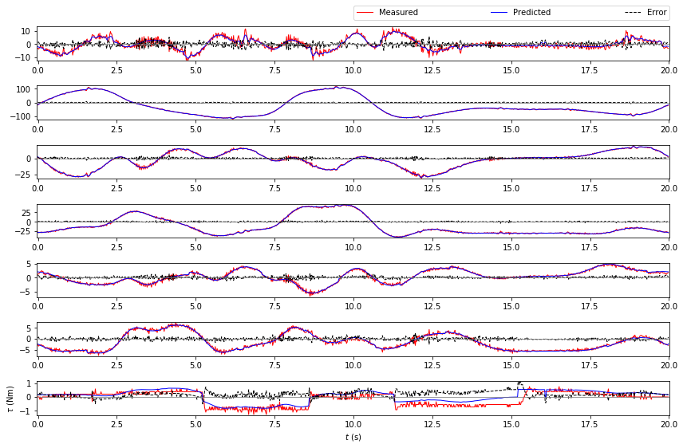

```python
from support_funcs.regr_data_proc import  plot_meas_pred_tau

import matplotlib.pyplot as plt
plt.rcParams['figure.figsize'] = [12,8]

proc = numpy.load(tmpfolder + 'procdata/' + indentification_traj + '_proc.npz')
t = proc['t']
tau = proc['tau']

tau_p = np.zeros(tau.shape)
tau_ps = W.dot(beta_ols)
for i in range(dof):
    tau_p[:, i] = tau_ps[i::dof].flatten()

base_freq = 0.05
trajectory_sampling_rate = 50
plot_data_num = int(1 / base_freq * trajectory_sampling_rate)
plot_meas_pred_tau(t[:plot_data_num], tau[:plot_data_num, :],
                   tau_p[:plot_data_num, :])
```

## Weighted Least Square (WLS)

```python
proc = numpy.load(tmpfolder + 'procdata/' + indentification_traj + '_proc.npz')
t = proc['t']
tau = proc['tau']

weight = np.max(tau, axis=0) - np.min(tau, axis=0)
print("weight: ")
print(weight)


# repeat the weight to generate a large vecoter for all the data
weights = 1.0/np.tile(weight, W.shape[0]/weight.shape[0])
```

```
weight:
[ 26.52     238.32      50.2229    91.8971    11.82858   15.36
   2.228576]
```

```python
weights[0:6]
```

```
array([0.03770739, 0.00419604, 0.01991124, 0.01088174, 0.084541  ,
       0.06510417])
```

```python
W_wls = np.multiply(W, np.asmatrix(weights).transpose())
omega_wls = np.multiply(omega.T, weights).T
Q1_wls,R1_wls = numpy.linalg.qr(W_wls)
rho1_wls = Q1_wls.T*omega_wls
```

```python
%time beta_wls = (R1_wls.T * R1_wls).I * R1_wls.T * rho1_wls
```

```
CPU times: user 94 ms, sys: 113 µs, total: 94.1 ms
Wall time: 8.99 ms
```

```python
numpy.savetxt(tmpfolder + 'solutions/' + indentification_traj + '_beta_wls.dat', beta_wls)
```

```python
rho2_norm_sqr_wls = numpy.linalg.norm(omega_wls - W_wls * beta_wls)**2
```

### plot measured and predicted torque

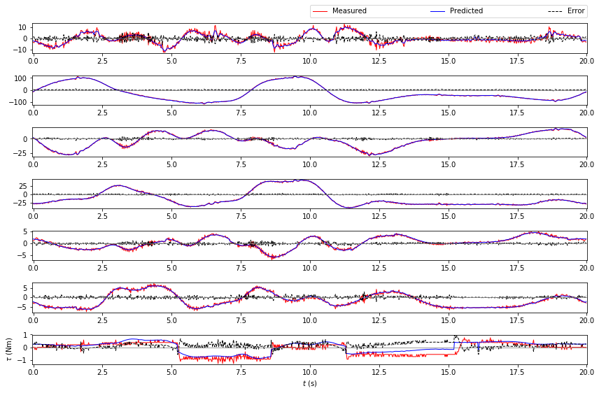

```python
from support_funcs.regr_data_proc import  plot_meas_pred_tau

import matplotlib.pyplot as plt
plt.rcParams['figure.figsize'] = [12,8]

proc = numpy.load(tmpfolder + 'procdata/' + indentification_traj + '_proc.npz')
t = proc['t']
tau = proc['tau']

tau_p = np.zeros(tau.shape)
tau_ps = W.dot(beta_wls)
for i in range(dof):
    tau_p[:, i] = tau_ps[i::dof].flatten()

base_freq = 0.05
trajectory_sampling_rate = 50
plot_data_num = int(1 / base_freq * trajectory_sampling_rate)
plot_meas_pred_tau(t[:plot_data_num], tau[:plot_data_num, :],
                   tau_p[:plot_data_num, :])
```

### Base Parameter Feasibility Test (BPFT) of OLS Solution

```python
dict_subs = dict(zip(beta_symbs, beta_ols))
lmis_ols_bpft = [ lmi_sdp.LMI_PD(mrepl(lmi.canonical().gts, dict_subs)) for lmi in DB_LMIs ]
```

```python
lmis_ols_bpft[0]
```

```
Matrix([
[L_1xx, L_1xy,                             L_1xz,     0,  l_1z, -l_1y],
[L_1xy, L_1yy,                             L_1yz, -l_1z,     0,  l_1x],
[L_1xz, L_1yz, -Ia_1 - L_2yy + 0.171312935758147,  l_1y, -l_1x,     0],
[    0, -l_1z,                              l_1y,   m_1,     0,     0],
[ l_1z,     0,                             -l_1x,     0,   m_1,     0],
[-l_1y,  l_1x,                                 0,     0,     0,   m_1]]) > 0
```

```python
variables_ols_bpft = list(delta_d)
objf_ols_bpft = 0  # no objective function - "find" problem
```

Testing with all solvers

**Just one of the following calls is sufficient to show feasibility/infeasibility**

```python
sol = sdpa_file(objf_ols_bpft, lmis_ols_bpft, variables_ols_bpft) # One can solve the output file at http://www.neos-server.org/neos/solvers/sdp:DSDP/SDPA.html for example.
```

```
SDPA file saved at: tmp/sdpa_dat/sdpa_input.dat-s
```

```python
#sol = dsdp5(objf_ols_bpft, lmis_ols_bpft, variables_ols_bpft)
```

```python
#sol = sdpa(objf_ols_bpft, lmis_ols_bpft, variables_ols_bpft)
```

```python
sol = csdp(objf_ols_bpft, lmis_ols_bpft, variables_ols_bpft)
```

```
CSDP 6.2.0
This is a pure dual feasibility problem.
Iter:  0 Ap: 0.00e+00 Pobj: -5.1538676e+03 Ad: 0.00e+00 Dobj:  0.0000000e+00
Iter:  1 Ap: 9.13e-01 Pobj: -9.2202281e+03 Ad: 8.37e-01 Dobj:  0.0000000e+00
Iter:  2 Ap: 7.13e-01 Pobj: -8.2360971e+03 Ad: 6.25e-01 Dobj:  0.0000000e+00
Iter:  3 Ap: 3.86e-01 Pobj: -6.9817108e+03 Ad: 5.61e-01 Dobj:  0.0000000e+00
Iter:  4 Ap: 6.12e-01 Pobj:  5.5098831e+04 Ad: 8.17e-02 Dobj:  0.0000000e+00
Iter:  5 Ap: 4.05e-01 Pobj:  3.9295392e+08 Ad: 7.14e-03 Dobj:  0.0000000e+00
Iter:  6 Ap: 2.96e-02 Pobj:  1.6975188e+13 Ad: 7.38e-04 Dobj:  0.0000000e+00
Declaring dual infeasibility.
Success: SDP is dual infeasible
Certificate of dual infeasibility: tr(CX)=1.00000e+00, ||A(X)||=4.81474e-13
Elements time: 0.000085
Factor time: 0.000111
Other time: 0.026315
Total time: 0.026510
```

```python
# sol = cvxopt_conelp(objf_ols_bpft, lmis_ols_bpft, variables_ols_bpft)
```

## Base Parameter Feasibility Correction (BPFC) ($\beta^\prime$)

```python
u = sympy.Symbol('u')
U_beta = BlockMatrix([[Matrix([u]),            (beta_ols - beta_symbs).T],
                 [beta_ols - beta_symbs,                 I(n_beta)]])
U_beta = U_beta.as_explicit()
```

```python
lmis_ols_bpfc = [LMI(U_beta)] + DB_LMIs_marg
```

```python
lmis_ols_bpfc[1]
```

```
Matrix([
[L_1xx, L_1xy,                 L_1xz,     0,  l_1z, -l_1y],
[L_1xy, L_1yy,                 L_1yz, -l_1z,     0,  l_1x],
[L_1xz, L_1yz, -Ia_1 - L_2yy + beta1,  l_1y, -l_1x,     0],
[    0, -l_1z,                  l_1y,   m_1,     0,     0],
[ l_1z,     0,                 -l_1x,     0,   m_1,     0],
[-l_1y,  l_1x,                     0,     0,     0,   m_1]]) >= Matrix([
[1.0e-6,      0,      0,      0,      0,      0],
[     0, 1.0e-6,      0,      0,      0,      0],
[     0,      0, 1.0e-6,      0,      0,      0],
[     0,      0,      0, 1.0e-6,      0,      0],
[     0,      0,      0,      0, 1.0e-6,      0],
[     0,      0,      0,      0,      0, 1.0e-6]])
```

```python
variables_ols_bpfc = [u] + list(beta_symbs) + list(delta_d)
```

```python
objf_ols_bpfc = u
```

```python
sol_ols_bpfc = solve_sdp(objf_ols_bpfc, lmis_ols_bpfc, variables_ols_bpfc)
```

```
CSDP 6.2.0
Iter:  0 Ap: 0.00e+00 Pobj: -7.8119921e+04 Ad: 0.00e+00 Dobj:  0.0000000e+00
Iter:  1 Ap: 4.33e-01 Pobj: -1.1234428e+05 Ad: 4.30e-01 Dobj:  3.7926796e+01
Iter:  2 Ap: 3.27e-01 Pobj: -1.4392101e+05 Ad: 3.00e-01 Dobj:  1.2857588e+02
Iter:  3 Ap: 4.24e-01 Pobj: -1.8305901e+05 Ad: 1.66e-01 Dobj:  2.4296024e+02
Iter:  4 Ap: 6.77e-01 Pobj: -1.9069817e+05 Ad: 1.27e-01 Dobj:  4.4876045e+02
Iter:  5 Ap: 3.36e-01 Pobj: -1.9259022e+05 Ad: 3.69e-01 Dobj:  4.0599640e+02
Iter:  6 Ap: 3.06e-01 Pobj: -1.8600066e+05 Ad: 5.58e-01 Dobj:  1.0229432e+03
Iter:  7 Ap: 3.57e-01 Pobj: -1.7260749e+05 Ad: 4.36e-01 Dobj:  1.6678588e+03
Iter:  8 Ap: 2.96e-01 Pobj: -1.5995721e+05 Ad: 2.90e-01 Dobj:  2.1824148e+03
Iter:  9 Ap: 2.32e-01 Pobj: -1.5152366e+05 Ad: 2.24e-01 Dobj:  2.6504529e+03
Iter: 10 Ap: 2.19e-01 Pobj: -1.4373764e+05 Ad: 1.80e-01 Dobj:  3.1053563e+03
Iter: 11 Ap: 2.67e-01 Pobj: -1.3281514e+05 Ad: 1.56e-01 Dobj:  3.5988095e+03
Iter: 12 Ap: 3.86e-01 Pobj: -1.1165155e+05 Ad: 1.53e-01 Dobj:  4.2114094e+03
Iter: 13 Ap: 2.86e-01 Pobj: -9.3130774e+04 Ad: 5.88e-01 Dobj:  4.9481628e+03
Iter: 14 Ap: 4.89e-01 Pobj: -6.9726646e+04 Ad: 1.00e+00 Dobj:  5.5925201e+03
Iter: 15 Ap: 7.97e-01 Pobj: -4.4339622e+04 Ad: 1.00e+00 Dobj:  6.7145763e+03
Iter: 16 Ap: 6.67e-01 Pobj: -2.8425217e+04 Ad: 1.00e+00 Dobj:  5.8229630e+03
Iter: 17 Ap: 6.78e-01 Pobj: -1.6678697e+04 Ad: 1.00e+00 Dobj:  2.9952786e+03
Iter: 18 Ap: 7.63e-01 Pobj: -7.8861826e+03 Ad: 1.00e+00 Dobj:  1.6037997e+03
Iter: 19 Ap: 7.23e-01 Pobj: -3.8933391e+03 Ad: 1.00e+00 Dobj:  6.9628385e+02
Iter: 20 Ap: 7.50e-01 Pobj: -1.7823798e+03 Ad: 1.00e+00 Dobj:  3.1986422e+02
Iter: 21 Ap: 7.16e-01 Pobj: -8.6242310e+02 Ad: 1.00e+00 Dobj:  1.3668699e+02
Iter: 22 Ap: 7.52e-01 Pobj: -3.8847023e+02 Ad: 1.00e+00 Dobj:  6.0841056e+01
Iter: 23 Ap: 7.18e-01 Pobj: -1.8607494e+02 Ad: 1.00e+00 Dobj:  2.5326988e+01
Iter: 24 Ap: 7.54e-01 Pobj: -8.2683364e+01 Ad: 1.00e+00 Dobj:  1.1099744e+01
Iter: 25 Ap: 7.21e-01 Pobj: -3.8827597e+01 Ad: 1.00e+00 Dobj:  4.7526605e+00
Iter: 26 Ap: 7.56e-01 Pobj: -1.6802904e+01 Ad: 1.00e+00 Dobj:  2.2755228e+00
Iter: 27 Ap: 7.23e-01 Pobj: -7.5677472e+00 Ad: 1.00e+00 Dobj:  1.1900820e+00
Iter: 28 Ap: 7.57e-01 Pobj: -3.0263222e+00 Ad: 1.00e+00 Dobj:  7.6468503e-01
Iter: 29 Ap: 7.22e-01 Pobj: -1.1617657e+00 Ad: 1.00e+00 Dobj:  5.7892076e-01
Iter: 30 Ap: 7.55e-01 Pobj: -2.5358657e-01 Ad: 1.00e+00 Dobj:  5.0152651e-01
Iter: 31 Ap: 7.26e-01 Pobj:  1.2418426e-01 Ad: 1.00e+00 Dobj:  4.6524714e-01
Iter: 32 Ap: 6.09e-01 Pobj:  2.7166133e-01 Ad: 1.00e+00 Dobj:  4.4973081e-01
Iter: 33 Ap: 9.41e-01 Pobj:  3.9748607e-01 Ad: 1.00e+00 Dobj:  4.4362295e-01
Iter: 34 Ap: 1.00e+00 Pobj:  4.2835834e-01 Ad: 1.00e+00 Dobj:  4.3970097e-01
Iter: 35 Ap: 1.00e+00 Pobj:  4.3498577e-01 Ad: 1.00e+00 Dobj:  4.3854027e-01
Iter: 36 Ap: 1.00e+00 Pobj:  4.3745640e-01 Ad: 1.00e+00 Dobj:  4.3812426e-01
Iter: 37 Ap: 1.00e+00 Pobj:  4.3791968e-01 Ad: 1.00e+00 Dobj:  4.3803778e-01
Iter: 38 Ap: 1.00e+00 Pobj:  4.3800634e-01 Ad: 1.00e+00 Dobj:  4.3802199e-01
Iter: 39 Ap: 1.00e+00 Pobj:  4.3802264e-01 Ad: 1.00e+00 Dobj:  4.3801896e-01
Iter: 40 Ap: 1.00e+00 Pobj:  4.3802464e-01 Ad: 1.00e+00 Dobj:  4.3802442e-01
Iter: 41 Ap: 9.50e-01 Pobj:  4.3802475e-01 Ad: 9.60e-01 Dobj:  4.3802472e-01
Success: SDP solved
Primal objective value: 4.3802475e-01
Dual objective value: 4.3802472e-01
Relative primal infeasibility: 1.27e-13
Relative dual infeasibility: 2.81e-09
Real Relative Gap: -1.28e-08
XZ Relative Gap: 3.76e-09
DIMACS error measures: 1.27e-13 0.00e+00 2.30e-08 0.00e+00 -1.28e-08 3.76e-09
Elements time: 0.002490
Factor time: 0.001689
Other time: 0.231870
Total time: 0.236049
```

```python
u_prime = sol_ols_bpfc[0,0]
beta_prime = sol_ols_bpfc[1:1+n_beta]
delta_d_prime = sol_ols_bpfc[1+n_beta:]
```

```python
u_prime
```

```
0.4380247214120618
```

### plot measured and predicted torque

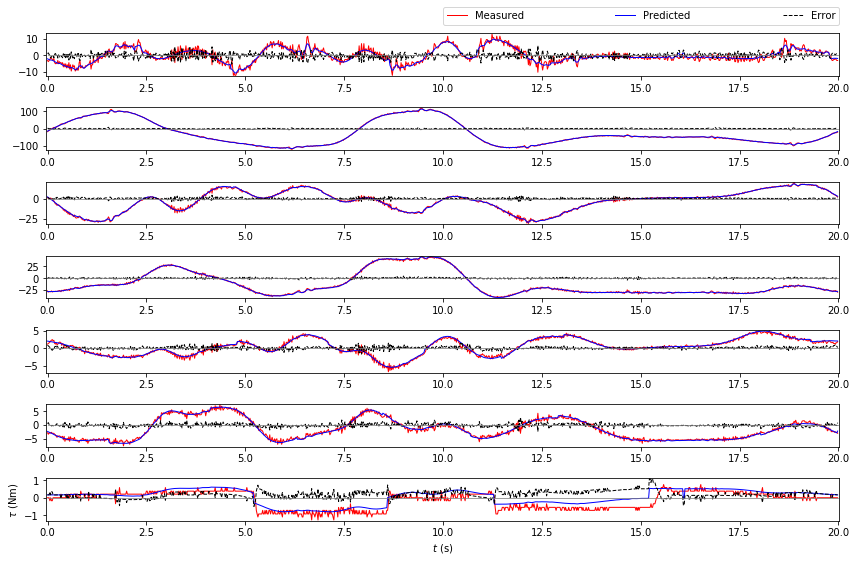

```python
from support_funcs.regr_data_proc import  plot_meas_pred_tau

import matplotlib.pyplot as plt
plt.rcParams['figure.figsize'] = [12,8]

proc = numpy.load(tmpfolder + 'procdata/' + indentification_traj + '_proc.npz')
t = proc['t']
tau = proc['tau']

tau_p = np.zeros(tau.shape)
tau_ps = W.dot(beta_prime)
for i in range(dof):
    tau_p[:, i] = tau_ps[i::dof].flatten()

base_freq = 0.05
trajectory_sampling_rate = 50
plot_data_num = int(1 / base_freq * trajectory_sampling_rate)
plot_meas_pred_tau(t[:plot_data_num], tau[:plot_data_num, :],
                   tau_p[:plot_data_num, :])
```

### Solution Double Check

```python
dict_subs = dict(zip(beta_symbs, beta_prime.flatten().tolist()[0]))
dict_subs.update(dict(zip(delta_d, delta_d_prime.flatten().tolist()[0])))

test = 'ok'
for i, DBi in enumerate(DB_blocks):
        m = numpy.matrix(mrepl(DBi, dict_subs)).astype(float)
        for v in numpy.linalg.eigvals( m ):
            if v <= 0.0:
                print i, v
                test = 'fail'
print(test)
```

```
ok
```

```python
numpy.savetxt(tmpfolder + 'solutions/' + indentification_traj + '_beta_prime.dat', beta_prime)
```

## Feasible Base Parameter Estimation with Weight Least Squares (FBPE-WLS) ($\beta^\star$)

```python
u = sympy.Symbol('u')
U_rho = BlockMatrix([[Matrix([u - rho2_norm_sqr_wls]), (rho1_wls - R1_wls*beta_symbs).T],
                     [rho1_wls - R1_wls*beta_symbs,                       I(n_beta)]])
U_rho = U_rho.as_explicit()
```

```python
lmis_fbpe_ols = [LMI(U_rho)] + DB_LMIs_marg
```

```python
variables_fbpe_ols = [u] + list(beta_symbs) + list(delta_d)
```

```python
objf_fbpe_ols = u
```

```python
sol_fbpe_ols = solve_sdp(objf_fbpe_ols, lmis_fbpe_ols, variables_fbpe_ols)
```

```
CSDP 6.2.0
Iter:  0 Ap: 0.00e+00 Pobj: -1.7254909e+04 Ad: 0.00e+00 Dobj:  0.0000000e+00
Iter:  1 Ap: 5.19e-01 Pobj: -9.1981891e+04 Ad: 5.22e-01 Dobj:  3.8790543e+02
Iter:  2 Ap: 3.40e-01 Pobj: -1.3960070e+05 Ad: 3.59e-01 Dobj:  1.2150594e+03
Iter:  3 Ap: 2.64e-01 Pobj: -1.8413935e+05 Ad: 3.29e-01 Dobj:  2.4193155e+03
Iter:  4 Ap: 2.60e-01 Pobj: -2.3629932e+05 Ad: 4.24e-01 Dobj:  4.0278279e+03
Iter:  5 Ap: 2.76e-01 Pobj: -3.0907406e+05 Ad: 5.40e-01 Dobj:  5.4645254e+03
Iter:  6 Ap: 3.49e-01 Pobj: -4.2610598e+05 Ad: 5.16e-01 Dobj:  6.7346024e+03
Iter:  7 Ap: 3.12e-01 Pobj: -5.4471835e+05 Ad: 4.92e-01 Dobj:  8.4352734e+03
Iter:  8 Ap: 3.12e-01 Pobj: -6.6047613e+05 Ad: 4.75e-01 Dobj:  1.0402598e+04
Iter:  9 Ap: 2.97e-01 Pobj: -7.4562920e+05 Ad: 4.67e-01 Dobj:  1.2454381e+04
Iter: 10 Ap: 2.73e-01 Pobj: -7.8733107e+05 Ad: 4.23e-01 Dobj:  1.4664843e+04
Iter: 11 Ap: 2.43e-01 Pobj: -7.9344586e+05 Ad: 3.73e-01 Dobj:  1.7055543e+04
Iter: 12 Ap: 2.17e-01 Pobj: -7.7917454e+05 Ad: 3.64e-01 Dobj:  1.9654169e+04
Iter: 13 Ap: 2.24e-01 Pobj: -7.3886382e+05 Ad: 4.68e-01 Dobj:  2.2496599e+04
Iter: 14 Ap: 4.47e-01 Pobj: -5.1986571e+05 Ad: 1.00e+00 Dobj:  2.2909159e+04
Iter: 15 Ap: 5.54e-01 Pobj: -3.9178320e+05 Ad: 9.95e-01 Dobj:  3.1664658e+04
Iter: 16 Ap: 3.23e-01 Pobj: -3.7127889e+05 Ad: 1.00e+00 Dobj:  3.4588542e+04
Iter: 17 Ap: 9.07e-01 Pobj: -2.3278808e+05 Ad: 1.00e+00 Dobj:  4.0347195e+04
Iter: 18 Ap: 9.08e-01 Pobj: -1.0715130e+05 Ad: 1.00e+00 Dobj:  3.3989254e+04
Iter: 19 Ap: 5.69e-01 Pobj: -7.2184282e+04 Ad: 1.00e+00 Dobj:  1.1435499e+04
Iter: 20 Ap: 6.85e-01 Pobj: -3.5897822e+04 Ad: 1.00e+00 Dobj:  6.5598211e+03
Iter: 21 Ap: 7.64e-01 Pobj: -1.5669729e+04 Ad: 1.00e+00 Dobj:  3.0777075e+03
Iter: 22 Ap: 7.27e-01 Pobj: -7.3956607e+03 Ad: 1.00e+00 Dobj:  1.3705715e+03
Iter: 23 Ap: 7.36e-01 Pobj: -3.4060656e+03 Ad: 1.00e+00 Dobj:  6.4409802e+02
Iter: 24 Ap: 7.25e-01 Pobj: -1.5898598e+03 Ad: 1.00e+00 Dobj:  3.0803592e+02
Iter: 25 Ap: 7.42e-01 Pobj: -7.0384758e+02 Ad: 1.00e+00 Dobj:  1.6207114e+02
Iter: 26 Ap: 7.27e-01 Pobj: -3.0677424e+02 Ad: 1.00e+00 Dobj:  9.6331198e+01
Iter: 27 Ap: 7.44e-01 Pobj: -1.1325791e+02 Ad: 1.00e+00 Dobj:  6.8970088e+01
Iter: 28 Ap: 7.30e-01 Pobj: -2.6465561e+01 Ad: 1.00e+00 Dobj:  5.7122119e+01
Iter: 29 Ap: 7.48e-01 Pobj:  1.5361723e+01 Ad: 1.00e+00 Dobj:  5.2366487e+01
Iter: 30 Ap: 7.34e-01 Pobj:  3.3735965e+01 Ad: 1.00e+00 Dobj:  5.0391823e+01
Iter: 31 Ap: 7.50e-01 Pobj:  4.2362953e+01 Ad: 1.00e+00 Dobj:  4.9625339e+01
Iter: 32 Ap: 7.34e-01 Pobj:  4.6056387e+01 Ad: 1.00e+00 Dobj:  4.9311088e+01
Iter: 33 Ap: 7.73e-01 Pobj:  4.7821478e+01 Ad: 1.00e+00 Dobj:  4.9184161e+01
Iter: 34 Ap: 7.00e-01 Pobj:  4.8487088e+01 Ad: 1.00e+00 Dobj:  4.9127716e+01
Iter: 35 Ap: 7.77e-01 Pobj:  4.8845816e+01 Ad: 1.00e+00 Dobj:  4.9105528e+01
Iter: 36 Ap: 1.00e+00 Pobj:  4.9031202e+01 Ad: 1.00e+00 Dobj:  4.9094536e+01
Iter: 37 Ap: 1.00e+00 Pobj:  4.9070221e+01 Ad: 1.00e+00 Dobj:  4.9088795e+01
Iter: 38 Ap: 1.00e+00 Pobj:  4.9083401e+01 Ad: 1.00e+00 Dobj:  4.9086894e+01
Iter: 39 Ap: 1.00e+00 Pobj:  4.9086103e+01 Ad: 1.00e+00 Dobj:  4.9086454e+01
Iter: 40 Ap: 1.00e+00 Pobj:  4.9086495e+01 Ad: 1.00e+00 Dobj:  4.9086473e+01
Iter: 41 Ap: 1.00e+00 Pobj:  4.9086524e+01 Ad: 1.00e+00 Dobj:  4.9086524e+01
Iter: 42 Ap: 9.58e-01 Pobj:  4.9086525e+01 Ad: 9.60e-01 Dobj:  4.9086525e+01
Success: SDP solved
Primal objective value: 4.9086525e+01
Dual objective value: 4.9086525e+01
Relative primal infeasibility: 1.67e-11
Relative dual infeasibility: 3.84e-10
Real Relative Gap: 1.29e-10
XZ Relative Gap: 7.54e-10
DIMACS error measures: 1.67e-11 0.00e+00 2.15e-09 0.00e+00 1.29e-10 7.54e-10
Elements time: 0.173316
Factor time: 0.002899
Other time: 0.292894
Total time: 0.469109
```

```python
u_star = sol_fbpe_ols[0,0]
beta_star = numpy.matrix(sol_fbpe_ols[1:1+n_beta])
delta_d_star = numpy.matrix(sol_fbpe_ols[1+n_beta:])
```

```python
u_star
```

```
49.08652531253851
```

### plot measured and predicted torque

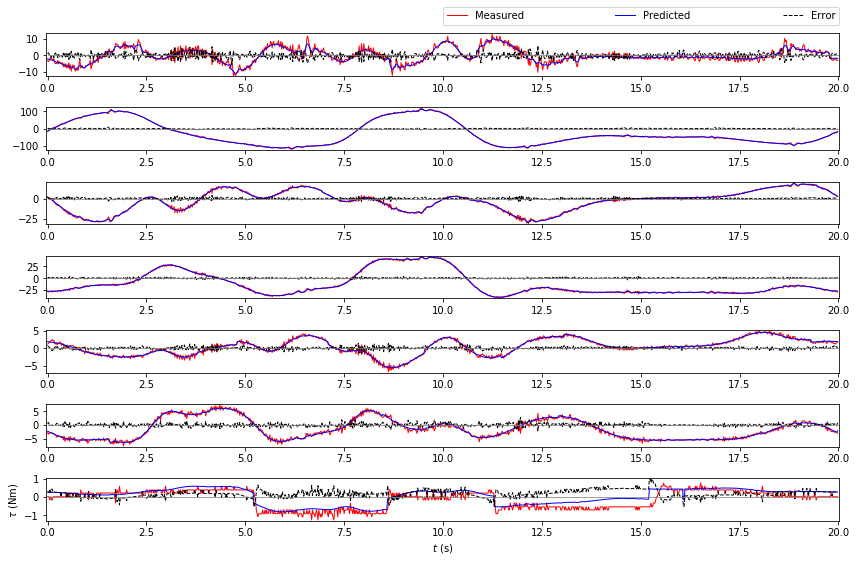

```python
# from support_funcs.regr_data_proc import  plot_meas_pred_tau

import matplotlib.pyplot as plt
plt.rcParams['figure.figsize'] = [12,8]

proc = numpy.load(tmpfolder + 'procdata/' + indentification_traj + '_proc.npz')
t = proc['t']
tau = proc['tau']

tau_p = np.zeros(tau.shape)
tau_ps = W.dot(beta_star)
for i in range(dof):
    tau_p[:, i] = tau_ps[i::dof].flatten()

base_freq = 0.05
trajectory_sampling_rate = 50
plot_data_num = int(1 / base_freq * trajectory_sampling_rate)
plot_meas_pred_tau(t[:plot_data_num], tau[:plot_data_num, :],
                   tau_p[:plot_data_num, :])
```

### Solution Double Check

```python
dict_subs = dict(zip(beta_symbs, beta_star.flatten().tolist()[0]))
dict_subs.update(dict(zip(delta_d, delta_d_star.flatten().tolist()[0])))

test = 'ok'
for DBi in DB_blocks:
        m = numpy.matrix(mrepl(DBi, dict_subs)).astype(float)
        for v in numpy.linalg.eigvals( m ):
            if v <= 0.0:
                print(v)
                test = 'fail'
print(test)
```

```
ok
```

```python
numpy.savetxt(tmpfolder + 'solutions/' + indentification_traj + '_beta_star.dat', beta_star)
```

## Additional Constraints on Centers-of-Mass ($\beta^{\star e}$)

```python
link_cuboid_hulls = [
[[ -0.140 , +0.140 ],[ -0.174 , +0.174 ],[ -0.084 , +0.346 ]],
[[ -0.084 , +0.084 ],[ -0.174 , +0.174 ],[ -0.084 , +0.170 ]],
[[ -0.090 , +0.040 ],[ -0.550 , +0.040 ],[ -0.045 , +0.045 ]],
[[ -0.045 , +0.095 ],[ -0.045 , +0.045 ],[ -0.050 , +0.830 ]],
[[ -0.045 , +0.045 ],[ -0.020 , +0.100 ],[ -0.045 , +0.045 ]],
[[ -0.045 , +0.045 ],[ -0.060 , +0.045 ],[ -0.020 , +0.060 ]],
[[ -0.045 , +0.045 ],[ -0.045 , +0.045 ],[ -0.018 , +0.001 ]],
]

robotmaxmass = 32.0
```

#### LMI Matrix Definition

```python
D_add_blocks = []
for i in range(rbt.dof):
    l = rbt.rbtdef.l[i]
    m = rbt.rbtdef.m[i]
    link_cuboid_hull = link_cuboid_hulls[i]
    for j in range(3):
        D_add_blocks.append( Matrix( [[  l[j] - m*link_cuboid_hull[j][0] ]] ) )
        D_add_blocks.append( Matrix( [[ -l[j] + m*link_cuboid_hull[j][1] ]] ) )

D_add_blocks.append(Matrix([robotmaxmass - sum(rbt.rbtdef.m)]))
```

#### Variable Change and LMI Definition

```python
DB_add_blocks = [ mrepl(Di, varchange_dict) for Di in D_add_blocks ]
```

```python
DB_add_LMIs = list(map(LMI_PD, DB_add_blocks))
```

```python
DB_add_LMIs_marg = list(map(lambda lm: LMI(lm, epsilon_safemargin*eye(lm.shape[0])) , DB_add_blocks))
```

```python
DB_add_LMIs_marg[0]
```

```
Matrix([[l_1x + 0.14*m_1]]) >= Matrix([[1.0e-6]])
```

```python
DB_add_LMIs_marg[-1]
```

```
Matrix([[-m_1 - m_2 - m_3 - m_4 - m_5 - m_6 - m_7 + 32.0]]) >= Matrix([[1.0e-6]])
```

### Testing $\beta^\star$ solution on new constraints

```python
dict_subs = dict(zip(beta_symbs, beta_star.flatten().tolist()[0]))
lmis_star_bpft_add = [ lmi_sdp.LMI_PD(mrepl(lmi.canonical().gts, dict_subs)) for lmi in DB_add_LMIs_marg ]
variables_star_bpft_add = list(delta_d)
objf_star_bpft_add = delta_d[0]
```

```python
sol_star_bpft_add = solve_sdp(objf_star_bpft_add, lmis_star_bpft_add, variables_star_bpft_add)
```

```
Constraint 1 is empty.
```

### Finding new solution

```python
lmis_fbpe_ols_add = [LMI(U_rho)] + DB_LMIs_marg + DB_add_LMIs_marg
```

```python
variables_fbpe_ols_add = [u] + list(beta_symbs) + list(delta_d)
```

```python
objf_fbpe_ols_add = u
```

```python
sol_fbpe_ols_add = solve_sdp(objf_fbpe_ols_add, lmis_fbpe_ols_add, variables_fbpe_ols_add)
```

```
CSDP 6.2.0
Iter:  0 Ap: 0.00e+00 Pobj: -7.7223416e+04 Ad: 0.00e+00 Dobj:  0.0000000e+00
Iter:  1 Ap: 5.18e-01 Pobj: -2.7916972e+05 Ad: 5.22e-01 Dobj:  3.2281122e+02
Iter:  2 Ap: 3.49e-01 Pobj: -4.1433212e+05 Ad: 3.97e-01 Dobj:  9.9618698e+02
Iter:  3 Ap: 2.33e-01 Pobj: -5.2288282e+05 Ad: 3.77e-01 Dobj:  1.8566271e+03
Iter:  4 Ap: 2.26e-01 Pobj: -6.4414476e+05 Ad: 4.90e-01 Dobj:  1.8264959e+03
Iter:  5 Ap: 5.52e-01 Pobj: -7.9690542e+05 Ad: 4.21e-01 Dobj:  3.4074745e+03
Iter:  6 Ap: 3.72e-01 Pobj: -9.2489498e+05 Ad: 4.01e-01 Dobj:  5.1476109e+03
Iter:  7 Ap: 3.17e-01 Pobj: -1.0407319e+06 Ad: 3.98e-01 Dobj:  7.2651919e+03
Iter:  8 Ap: 2.79e-01 Pobj: -1.1369653e+06 Ad: 5.07e-01 Dobj:  9.0750826e+03
Iter:  9 Ap: 3.29e-01 Pobj: -1.1875475e+06 Ad: 5.50e-01 Dobj:  1.0527979e+04
Iter: 10 Ap: 3.35e-01 Pobj: -1.1439363e+06 Ad: 6.15e-01 Dobj:  1.1907072e+04
Iter: 11 Ap: 3.49e-01 Pobj: -1.0060265e+06 Ad: 6.05e-01 Dobj:  1.3652120e+04
Iter: 12 Ap: 3.27e-01 Pobj: -8.3984683e+05 Ad: 1.00e+00 Dobj:  1.6015717e+04
Iter: 13 Ap: 3.01e-01 Pobj: -7.5353621e+05 Ad: 1.00e+00 Dobj:  1.7794034e+04
Iter: 14 Ap: 7.19e-01 Pobj: -4.4903920e+05 Ad: 1.00e+00 Dobj:  2.1034672e+04
Iter: 15 Ap: 9.41e-01 Pobj: -2.2637170e+05 Ad: 1.00e+00 Dobj:  2.1577878e+04
Iter: 16 Ap: 9.56e-01 Pobj: -1.1021990e+05 Ad: 1.00e+00 Dobj:  1.7323563e+04
Iter: 17 Ap: 9.56e-01 Pobj: -4.9629494e+04 Ad: 1.00e+00 Dobj:  6.3472239e+03
Iter: 18 Ap: 6.74e-01 Pobj: -2.6895565e+04 Ad: 1.00e+00 Dobj:  2.4937167e+03
Iter: 19 Ap: 7.52e-01 Pobj: -1.2423493e+04 Ad: 1.00e+00 Dobj:  1.3496510e+03
Iter: 20 Ap: 8.79e-01 Pobj: -2.8623858e+03 Ad: 1.00e+00 Dobj:  3.5157767e+02
Iter: 21 Ap: 7.91e-01 Pobj: -1.6602679e+03 Ad: 1.00e+00 Dobj:  2.2285368e+02
Iter: 22 Ap: 7.73e-01 Pobj: -7.7612771e+02 Ad: 1.00e+00 Dobj:  1.2075744e+02
Iter: 23 Ap: 8.16e-01 Pobj: -2.9950049e+02 Ad: 1.00e+00 Dobj:  7.9465654e+01
Iter: 24 Ap: 8.10e-01 Pobj: -1.0066950e+02 Ad: 1.00e+00 Dobj:  6.1575593e+01
Iter: 25 Ap: 7.98e-01 Pobj: -1.7057206e+01 Ad: 1.00e+00 Dobj:  5.4333631e+01
Iter: 26 Ap: 8.02e-01 Pobj:  2.0121039e+01 Ad: 1.00e+00 Dobj:  5.1362666e+01
Iter: 27 Ap: 8.04e-01 Pobj:  3.6431233e+01 Ad: 1.00e+00 Dobj:  5.0091129e+01
Iter: 28 Ap: 8.05e-01 Pobj:  4.3587460e+01 Ad: 1.00e+00 Dobj:  4.9538888e+01
Iter: 29 Ap: 8.06e-01 Pobj:  4.6715812e+01 Ad: 1.00e+00 Dobj:  4.9295547e+01
Iter: 30 Ap: 8.05e-01 Pobj:  4.8061545e+01 Ad: 1.00e+00 Dobj:  4.9189440e+01
Iter: 31 Ap: 8.07e-01 Pobj:  4.8648564e+01 Ad: 1.00e+00 Dobj:  4.9141768e+01
Iter: 32 Ap: 8.12e-01 Pobj:  4.8906636e+01 Ad: 1.00e+00 Dobj:  4.9118946e+01
Iter: 33 Ap: 8.17e-01 Pobj:  4.9018571e+01 Ad: 1.00e+00 Dobj:  4.9108043e+01
Iter: 34 Ap: 7.73e-01 Pobj:  4.9056218e+01 Ad: 1.00e+00 Dobj:  4.9103289e+01
Iter: 35 Ap: 8.37e-01 Pobj:  4.9081412e+01 Ad: 1.00e+00 Dobj:  4.9100075e+01
Iter: 36 Ap: 8.44e-01 Pobj:  4.9091304e+01 Ad: 1.00e+00 Dobj:  4.9098694e+01
Iter: 37 Ap: 8.60e-01 Pobj:  4.9095511e+01 Ad: 1.00e+00 Dobj:  4.9098018e+01
Iter: 38 Ap: 9.10e-01 Pobj:  4.9097240e+01 Ad: 1.00e+00 Dobj:  4.9097737e+01
Iter: 39 Ap: 9.34e-01 Pobj:  4.9097690e+01 Ad: 1.00e+00 Dobj:  4.9097756e+01
Iter: 40 Ap: 9.39e-01 Pobj:  4.9097772e+01 Ad: 1.00e+00 Dobj:  4.9097785e+01
Iter: 41 Ap: 9.39e-01 Pobj:  4.9097784e+01 Ad: 1.00e+00 Dobj:  4.9097786e+01
Iter: 42 Ap: 9.04e-01 Pobj:  4.9097785e+01 Ad: 9.51e-01 Dobj:  4.9097786e+01
Success: SDP solved
Primal objective value: 4.9097785e+01
Dual objective value: 4.9097786e+01
Relative primal infeasibility: 1.28e-13
Relative dual infeasibility: 1.04e-10
Real Relative Gap: 1.80e-09
XZ Relative Gap: 1.95e-09
DIMACS error measures: 1.28e-13 0.00e+00 1.09e-09 0.00e+00 1.80e-09 1.95e-09
Elements time: 0.182190
Factor time: 0.001832
Other time: 0.512289
Total time: 0.696311
```

```python
u_starextra = sol_fbpe_ols_add[0,0]
beta_starextra = numpy.matrix(sol_fbpe_ols_add[1:1+n_beta])
delta_d_starextra = numpy.matrix(sol_fbpe_ols_add[1+n_beta:])
```

```python
u_starextra
```

```
49.0977856496663
```

### Solution Double Check

```python
dict_subs = dict(zip(beta_symbs, beta_starextra.flatten().tolist()[0]))
dict_subs.update(dict(zip(delta_d, delta_d_starextra.flatten().tolist()[0])))

test = 'ok'
for DBi in (DB_blocks + DB_add_blocks):
        m = numpy.matrix(mrepl(DBi, dict_subs)).astype(float)
        for v in numpy.linalg.eigvals( m ):
            if v <= 0.0: test = 'fail'
print(test)
```

```
ok
```

```python
numpy.savetxt(tmpfolder + 'solutions/' + indentification_traj + '_beta_starextra.dat', beta_starextra)
```

### Inertia Matrix Definiteness Tests

```python
def test_mass_matrix_psd(beta_solution):
    K = rbt.dyn.Pb.T + rbt.dyn.Kd * rbt.dyn.Pd.T
    A = numpy.matrix(K).astype(float)
    b = numpy.matrix(beta_solution).astype(float)
    x = numpy.linalg.pinv(A) * b
    d_test = x

    M_func_def = sympybotics.robotcodegen.robot_code_to_func( 'python', rbt.M_code, 'M', 'M_func', rbt.rbtdef)
    exec(M_func_def, globals())
    global sin, cos
    from math import sin, cos

    ntests = 10000

    ok = 0
    nok = 0
    for i in range(ntests):
        q_test = numpy.random.rand(rbt.dof)
        M_out = M_func( numpy.array(d_test).flatten().tolist(), q_test)
        M = numpy.matrix(M_out).reshape((rbt.dof,rbt.dof))
        try:
            c = numpy.linalg.cholesky(M)
        except:
            nok += 1
            continue
        ok += 1

    print 'ok     %8i  %3i%%'%(ok, 100.0*ok/ntests)
    print 'not ok %8i  %3i%%'%(nok, 100.0*nok/ntests)
    if nok > 0 :
        print('\nNot PSD -> Not feasible!')
    else:
        print('\nSeems feasible.')
```

```python
beta_ols = numpy.matrix(numpy.loadtxt(tmpfolder + 'solutions/traj1_beta_ols.dat')).T
test_mass_matrix_psd(beta_ols)
```

```
ok            0    0%
not ok    10000  100%

Not PSD -> Not feasible!
```

```python
beta_wls = numpy.matrix(numpy.loadtxt(tmpfolder + 'solutions/traj1_beta_wls.dat')).T
test_mass_matrix_psd(beta_wls)
```

```
ok            0    0%
not ok    10000  100%

Not PSD -> Not feasible!
```

```python
beta_prime = numpy.matrix(numpy.loadtxt(tmpfolder + 'solutions/traj1_beta_prime.dat')).T
test_mass_matrix_psd(beta_prime)
```

```
ok        10000  100%
not ok        0    0%

Seems feasible.
```

```python
beta_star = numpy.matrix(numpy.loadtxt(tmpfolder + 'solutions/traj1_beta_star.dat')).T
test_mass_matrix_psd(beta_star)
```

```
ok        10000  100%
not ok        0    0%

Seems feasible.
```

```python
beta_starextra = numpy.matrix(numpy.loadtxt(tmpfolder + 'solutions/traj1_beta_starextra.dat')).T
test_mass_matrix_psd(beta_starextra)
```

```
ok        10000  100%
not ok        0    0%

Seems feasible.
```

# 5 - Regression Model Validation

```python
import numpy as np
import sympybotics
import pickle

from collections import OrderedDict
from support_funcs.utils import ListTable
```

```python
with open(tmpfolder +  'robotmodels/xMate7p.pkl', 'rb' ) as file:
          rbt = pickle.load( file )
```

```python
def analyse(W, omega, R1, beta):
    from numpy import matrix, mean
    from numpy.linalg import cond, norm

    p = dict()

    n = W.shape[0]

    omega_norm = norm(omega)
    omega_mean = mean(omega)

    p['err'] = norm(omega - W * beta)
    p['merr'] = p['err'] / n

    p['se'] = p['err']**2
    p['mse'] = p['se']/(n-W.shape[1])
    p['rmse'] = p['mse']**0.5

    C = p['mse'] * (R1.T * R1).I
    p['sd'] = np.sqrt(C.diagonal()).T
    p['sd%'] = 100. * p['sd'] / np.abs(beta)

    p['relerr'] = p['err']/ omega_norm
    p['relerr%'] = p['relerr']*100.

    p['1-r2'] = p['err']**2 / norm(omega - omega_mean)**2
    p['r2'] = 1 - p['1-r2']

    return p
```

```python
# trajs = OrderedDict([('id', 'traj1'),
#                      ('vA', 'traj2'),
#                      ('vB', 'traj3'),
#                      ('vC', 'traj4')])

trajs = OrderedDict([('id', 'traj1'),
                     ('vA', 'traj2'),
                     ('vB', 'traj3')])

betas = OrderedDict([('beta_ols', 'B^'),
                     ('beta_wls', 'B~'),
                     ('beta_prime', 'B\''),
                     ('beta_star', 'B*'),
                     ('beta_starextra', 'B*e')])
```

```python
solutions_beta = {betaname:np.matrix(np.loadtxt(tmpfolder + 'solutions/%s_%s.dat'%(trajs['id'], betaname))).T for betaname in betas}
```

```python
analysis = dict()

for traj in trajs:
    from numpy.linalg import cond

    print(traj)

    analysis[traj] = dict()

    regr_mats = np.load(tmpfolder + 'procdata/' + trajs[traj] + '_regr.npz')
    W = np.matrix(regr_mats['W'])
    omega = np.matrix(regr_mats['omega'])
    R1 = np.matrix(regr_mats['R1'])

    analysis[traj]['cond'] = cond(W)

    analysis[traj]['betas'] = dict()

    for betaname in betas:
        beta = solutions_beta[betaname]
        analysis[traj]['betas'][betaname] = analyse(W, omega, R1, beta)

    del W, omega, R1
```

```
id
vA
vB
```

```python
prop = lambda x: x['relerr%']
form = '%.2f'

table = ListTable()
table.append([''] + ['cond'] + betas.values())
for (traj, trajname) in zip(trajs, ['identification', 'validation A', 'validation B', 'validation C']):
    row = [traj] + ['%.0f'%analysis[traj]['cond']] + [ form%prop(analysis[traj]['betas'][b]) for b in betas]
    table.append(row)
table
```

|  | cond | B^ | B~ | B' | B* | B*e |
| --- | --- | --- | --- | --- | --- | --- |
| id | 82 | 3.62 | 3.74 | 3.67 | 3.76 | 3.76 |
| vA | 134 | 3.70 | 3.85 | 3.76 | 3.87 | 3.86 |
| vB | 55 | 4.63 | 4.72 | 4.64 | 4.71 | 4.72 |

```python
import yaml, sympy
with open(datafolder + 'robotparams/ur10_cad.yml', 'r') as f:
    wam7_cad = yaml.load(f)
delta_cad = sympy.Matrix([wam7_cad.get(str(d), d) for d in rbt.dyn.dynparms])
beta_cad = (rbt.dyn.Pb.T + rbt.dyn.Kd * rbt.dyn.Pd.T) * delta_cad
```

### plot measured and predicted torque

```python
indentification_traj = 'traj1'
regr_mats = numpy.load(tmpfolder + 'procdata/' + indentification_traj + '_regr.npz')
W = numpy.matrix(regr_mats['W'])
```

```python
# from support_funcs.regr_data_proc import  plot_meas_pred_tau

# import matplotlib.pyplot as plt
# plt.rcParams['figure.figsize'] = [12,8]

# proc = numpy.load(tmpfolder + 'procdata/' + indentification_traj + '_proc.npz')
# t = proc['t']
# tau = proc['tau']

# tau_p = np.zeros(tau.shape)
# tau_ps = W.dot(numpy.matrix(beta_cad))
# for i in range(dof):
#     tau_p[:, i] = tau_ps[i::dof].flatten()

# base_freq = 0.05
# trajectory_sampling_rate = 50
# plot_data_num = int(1 / base_freq * trajectory_sampling_rate)
# plot_meas_pred_tau(t[:plot_data_num], tau[:plot_data_num, :],
#                    tau_p[:plot_data_num, :])
```

### $\beta^{cad}$ Double Check

```python
# def  test_lmi_matrix_psd(delta_solution):
#     dict_subs = dict(zip(delta, delta_solution))

#     test = 'ok'
#     for Di in D_blocks:
#             m = numpy.matrix(mrepl(Di, dict_subs)).astype(float)
#             for v in numpy.linalg.eigvals( m ):
#                 if v <= 0.0:
#                     print(v)
#                     test = 'fail'
#     print(test)
```

```python
# test_lmi_matrix_psd(delta_cad)
```

```python
# test_mass_matrix_psd(beta_cad)
```

```python
# form = '%.4g'

# import sympy

# table = ListTable()
# header = ['', 'Bcad', 'B^', '% std dev B^', 'B*ext']
# table.append(header)
# for i, b in enumerate(rbt.dyn.baseparms.n()):
#     if beta_cad[i].is_Number:
#         cad_v = sympy.N(beta_cad[i], 4)
#     elif beta_cad[i].is_Symbol:
#         cad_v = '---'
#     else:
#         cad_v = sympy.N(beta_cad[i], 4)
#     row = ['%.7s ...'%b if len(str(b)) > 107 else str(b), cad_v]
#     row += [form%solutions_beta['beta_ols'][i,0], '%.2g'%analysis['id']['betas']['beta_ols']['sd%'][i,0]]
#     row += [form%solutions_beta['beta_starextra'][i,0]]
#     table.append(row)
# table
```

## Torque Plot

```python
traj = 'vA'
betaname = 'beta_star'
```

```python
regr_mats = np.load(tmpfolder + 'procdata/' + trajs[traj] + '_regr.npz')
W = np.matrix(regr_mats['W'])
omega = np.matrix(regr_mats['omega'])

regr_mats = np.load(tmpfolder + 'procdata/' + trajs[traj] + '_proc.npz')
t = regr_mats['t']
tau_proc = np.matrix(regr_mats['tau'])

regr_mats = np.load(tmpfolder + 'procdata/' + trajs[traj] + '_raw.npz')
tau_raw = np.matrix(regr_mats['tau'])
```

```python
beta_solution = np.matrix(np.loadtxt(tmpfolder + 'solutions/%s_%s.dat'%(trajs['id'], betaname))).T
```

```python
tau = tau_raw
```

```python
omega_pred = W * beta_solution
tau_pred = omega_pred.reshape( omega_pred.shape[0]/tau.shape[1], tau.shape[1] )
err_pred = tau - tau_pred
```

```python
joint = 7
firsts = 2000
s=tau_raw.shape[0]
```

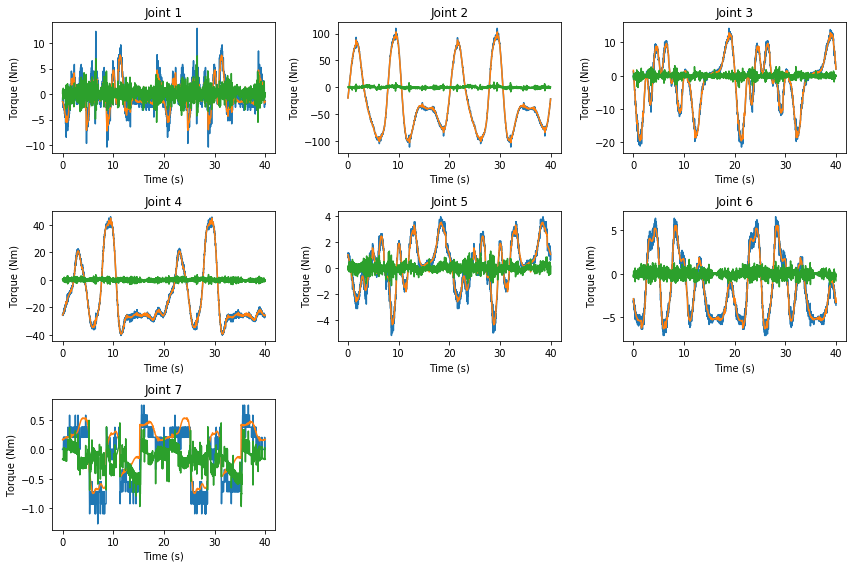

```python
from matplotlib import pyplot as plt
plt.close()

plt.figure(figsize=(12,8))

axes = []
for i in range(tau.shape[1]):
    ax = plt.subplot(3, 3, i+1)
    ax.plot(t[:firsts],tau_raw[:,i][:firsts], label="Measured torque")
    ax.plot(t[:firsts],tau_pred[:,i][:firsts], label="Estimated torque")
    ax.plot(t[:firsts],err_pred[:,i][:firsts], label="Error")
    ax.set_title( "Joint %d"%(i+1) )
    plt.xlabel("Time (s)")
    plt.ylabel("Torque (Nm)")
    axes.append(ax)

plt.tight_layout()

plt.show()
```

```python
delta_starextra = Pb*beta_starextra + (-Pb*rbt.dyn.Kd+rbt.dyn.Pd)*delta_d_starextra
K = np.matrix(Pb.T+rbt.dyn.Kd*rbt.dyn.Pd.T).astype(float)
delta_starextra_min = np.linalg.pinv(K)*beta_starextra
```

```python
np.testing.assert_array_almost_equal(K * delta_starextra ,beta_starextra, 10)
```

```python
for i in range(delta_starextra.shape[0]):
     print 'double ' + repr(rbt.dyn.dynparms[i]) + '    =    ' + repr(delta_starextra[i,0]) + ';'
```

```
double L_1xx    =    45767233679771.0;
double L_1xy    =    0;
double L_1xz    =    0;
double L_1yy    =    45767233679771.0;
double L_1yz    =    0;
double L_1zz    =    1.00978438795363e-6;
double l_1x    =    0;
double l_1y    =    0;
double l_1z    =    3.73746168769108e-6;
double m_1    =    2.85302419902746e-5;
double Ia_1    =    1.00978438794613e-6;
double fv_1    =    0.626152045162406;
double fc_1    =    1.24245715487060;
double L_2xx    =    0.688821170770978;
double L_2xy    =    -0.144065795379853;
double L_2xz    =    0.0164889764559336;
double L_2yy    =    0.0684269089764906;
double L_2yz    =    -0.0439109548286903;
double L_2zz    =    0.469045237930894;
double l_2x    =    -0.129602474859708;
double l_2y    =    -3.02386869202830;
double l_2z    =    -0.221769569295294;
double m_2    =    20.4819922003437;
double Ia_2    =    2.63256744793574e-6;
double fv_2    =    0.846886533491693;
double fc_2    =    1.10084206349772;
double L_3xx    =    0.497256834680426;
double L_3xy    =    0.139908849595394;
double L_3xz    =    -0.174609808522232;
double L_3yy    =    0.639313526364689;
double L_3yz    =    -0.0800838089558495;
double L_3zz    =    0.0679091930459193;
double l_3x    =    0.0401353597510817;
double l_3y    =    0.0401349677438217;
double l_3z    =    -0.0451522773920888;
double m_3    =    1.00341031676238;
double Ia_3    =    1.01946962401355e-6;
double fv_3    =    0.0335838705058075;
double fc_3    =    0.692417304784231;
double L_4xx    =    0.264078350004354;
```

[output cut: 36 more lines]

```
double fv_6    =    0.0552179075319546;
double fc_6    =    0.321536407928786;
double L_7xx    =    0.105659556249081;
double L_7xy    =    -0.000342015255829974;
double L_7xz    =    -0.0357268732549593;
double L_7yy    =    0.0488805751129931;
double L_7yz    =    -0.0255562308307120;
double L_7zz    =    0.0269949855027368;
double l_7x    =    -0.0209355227114017;
double l_7y    =    0.0141948849066373;
double l_7z    =    -0.0121662596067956;
double m_7    =    0.675959719449703;
double Ia_7    =    9.99415854754447e-7;
double fv_7    =    0.235768993062905;
double fc_7    =    0.283177872827077;
```

```python
for i in range(delta_starextra.shape[0]):
     print 'double ' + repr(rbt.dyn.dynparms[i]) + '    =    ' + repr(delta_starextra_min[i,0]) + ';'
```

```
double L_1xx    =    -4.4334280309591757e-17;
double L_1xy    =    1.2462804869389537e-16;
double L_1xz    =    4.0615605935297515e-16;
double L_1yy    =    5.545471482498301e-19;
double L_1yz    =    2.080519307996198e-16;
double L_1zz    =    0.022870324665642594;
double l_1x    =    -2.7517845271007045e-17;
double l_1y    =    -1.0045735430956018e-15;
double l_1z    =    1.4900342115351618e-16;
double m_1    =    -3.1674066246036997e-16;
double Ia_1    =    0.022870324665642094;
double fv_1    =    0.6261520451624067;
double fc_1    =    1.242457154870602;
double L_2xx    =    0.000182045451666335;
double L_2xy    =    -0.14406579537985426;
double L_2xz    =    0.016488976455933623;
double L_2yy    =    0.022688279213976426;
double L_2yz    =    -0.043910954828689994;
double L_2zz    =    -0.08692631252922678;
double l_2x    =    -0.12960247485970844;
double l_2y    =    -2.59740382177693;
double l_2z    =    2.971518417193312e-16;
double m_2    =    -3.9910616794203297e-16;
double Ia_2    =    -0.08692631252922678;
double fv_2    =    0.8468865334916929;
double fc_2    =    1.1008420634977172;
double L_3xx    =    -0.05946840461825431;
double L_3xy    =    0.1399088495953948;
double L_3xz    =    -0.1746098085222322;
double L_3yy    =    -0.027275862459306355;
double L_3yz    =    -0.0800838089558489;
double L_3zz    =    0.1777733425712348;
double l_3x    =    0.040135359751081436;
double l_3y    =    0.034872841359811474;
double l_3z    =    2.521502588084066;
double m_3    =    1.1197607771570928;
double Ia_3    =    1.019469624192081e-06;
double fv_3    =    0.03358387050580759;
double fc_3    =    0.6924173047842304;
double L_4xx    =    0.19343054162532847;
```

[output cut: 36 more lines]

```
double fv_6    =    0.05521790753195456;
double fc_6    =    0.3215364079287858;
double L_7xx    =    0.03990411357745756;
double L_7xy    =    -0.00034201525582997416;
double L_7xz    =    -0.035726873254959254;
double L_7yy    =    -0.016874867558629242;
double L_7yz    =    -0.02555623083071202;
double L_7zz    =    0.02699498550273681;
double l_7x    =    -0.02093552271140168;
double l_7y    =    0.01419488490663729;
double l_7z    =    0.10038040701610265;
double m_7    =    1.4794683080435673;
double Ia_7    =    9.99415854754447e-07;
double fv_7    =    0.2357689930629051;
double fc_7    =    0.2831778728270766;
```

### (generate readme and notebook preview)

```python
def save_files():
    from IPython.display import display, Javascript
    Javascript('IPython.notebook.save_notebook()')

    import json
    with open('xMate7p Dynamic Parameter Identification.ipynb', 'r') as f:
        d = json.load(f)
    with open('README.md', 'w') as f:
        f.write(''.join(d['worksheets'][0]['cells'][0]['source']).encode('UTF-8'))

    !ipython nbconvert "xMate7p Dynamic Parameter Identification.ipynb" --to html
```

```python
#save_files()
```

```python
#!git status
```

```python
#!git commit -a -m "Add automathic README.md file generator"
```

```python
#!git push
```